# Assignment 5

Alex Ivina

November 26, 2018

1. Male and female graduate enrollment (1967 - 2015). Compare trends in total graduate enrollment for males and females (including full-time/part-time and private/public universities) in the United States from 1967 - 2015. Describe your results statistically, graphically and in text.

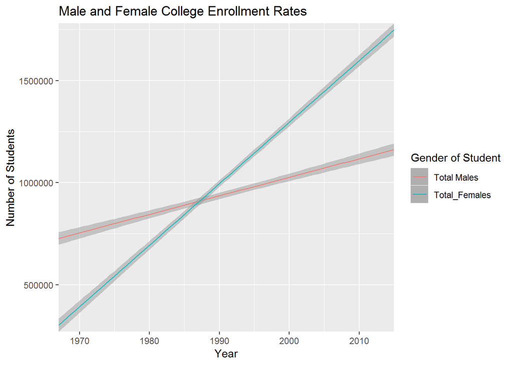

male_enrollment = -17112153 + 9069(Year)

Total_Females- Year significantly predicts college enrollment rates for females (b = 30126, t(47) = 51.66, p < 0.001) with a strong positive correlation between the two (Pearson’s r = 0.99). The overall model (Total Female enrollment = -58955502 + 30126 (Year) explains a significant amount of variance in enrollment rate (F(1,47) = 2669, p < 0.001, R2 = 0.9827).

2. Shifts in female PhD recipients by field (1985, 2000, and 2015). Describe if and how there was a shift in PhDs awarded to females in four fields (Physical and Earth Sciences, Engineering, Education, and Humanities & Arts) in 1985, 2000, and 2015. Describe your results statistically, in a graph or table, and in text. Note: There are several ways that you can interpret this question. You are invited to decide which you think is/are most interesting. Just be really clear about what you are asking/answering in your report.

Changes in field of study

|  | 1985 | 2000 | 2015 |
| --- | --- | --- | --- |
| Female_Physical_science | 0.0529647 | 0.0563675 | 0.0782585 |
| Female_Engineering | 0.0184306 | 0.0462192 | 0.0905799 |
| Female_Education | 0.3249558 | 0.2304892 | 0.1378577 |
| Female_Humanities | 0.1295727 | 0.1473719 | 0.1114829 |

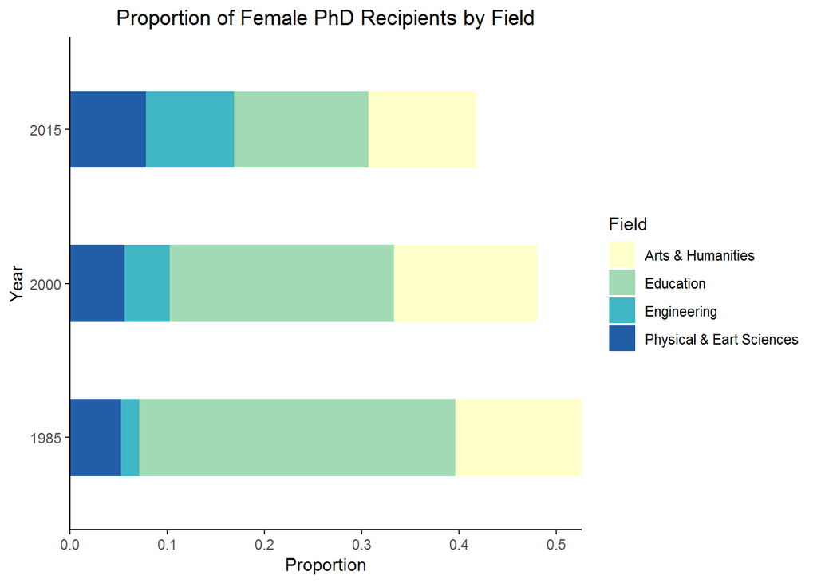

3. Male and female salaries for starting postdoctoral and other employment positions (2015). Compare median salaries for male and female doctorate recipients in 2015. Answer these two questions: Does median salary differ significantly between male and female starting postdoc positions? Does median salary differ significantly between male and female PhD recipients in non-postdoc employment positions?

Communicating Statistical Results: Non-Parametric Wilcomxon Signed Rank anaylsis for data collected from 15 fields of study in the year 2015 revealed that the median salaries (in dollars) differed significantly for male and female PhD recipients in non-postdoc employment positions (V= 101, p=0.003). In all fields except Physics & Astonomy, men recieved either equal or moderately higher salaries(cliffs delta=0.213).

However, a separate non-parametric wimcoxon signed rank test for PhD recipients starting posdoc positions revealed that there was *not* a signficant difference between salaries for males and females (V=19.5, p=.888). In several fields of study, males and females recieved the exact same salary. Females recieved a slightly higher median salary in some fields, while males were paid slightly more in others resulting in a negligible association between salaries of the two groups (cliff’s delta=.04).

4. Exploring academic salaries for professors in U.S. colleges. Explore relationships between variables in the ‘Faculty salary data (2008 - 2009 survey)’ dataset. Develop a model describing faculty salary based on data for faculty sex, rank, years in current position, field, and number of years since doctoral degree was earned. You should make decisions regarding which variables should remain in your final model. Describe the results qualitatively and quantitatively (i.e., don’t just report the statistical results of the model – make sure you describe interesting findings in text). You can also discuss any concerns that you have with the model(s) you present, if any

|  | *Dependent variable:* |
| --- | --- |
|  | salary |
| years_since_phd | 2,391.078*** |
|  | (237.860) |
| years_employed | 1,473.923*** |
|  | (341.469) |
| sexMale | 8,188.367** |
|  | (4,090.693) |
| disciplineTheoretical | -14,999.330*** |
|  | (2,487.418) |
| years_since_phd:years_employed | -62.226*** |
|  | (7.153) |
| Constant | 67,764.100*** |
|  | (4,849.353) |
| Observations | 397 |
| R<sup>2</sup> | 0.383 |
| Adjusted R<sup>2</sup> | 0.375 |
| Residual Std. Error | 23,947.360 (df = 391) |
| F Statistic | 48.501*** (df = 5; 391) |
| *Note:* | p<0.1; p<0.05; p<0.01 |